# lab3

### Task 2.1

Display vector field of autonomous differential equation: $$ y' = 2 - y^2 - y$$ at points $\pm 1, \pm 2, \pm 3, \pm 4$

```python
import numpy as np
import matplotlib.pyplot as plt
```

```
Here we will do it as given task example demands it (though latter provides neither boost in understanding of vector
fields nor greater understanding of particular diff. equation, so we will do it in another way later)
```

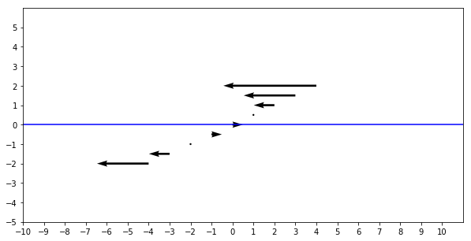

```python
fig = plt.gcf()
fig.set_size_inches(10, 5)
xticks = np.arange(-10, 11, 1)
yticks = np.arange(-5, 6, 1)
plt.axis((-10, 11, -5, 6))
ax = plt.gca()
ax.set_xticks(xticks)
ax.set_yticks(yticks)
# plt.grid(axis='both')

f = lambda x: 2 - x**2 - x

X = np.arange(-4, 5)
Y = np.linspace(-2, 2, 9)
XX, YY = np.meshgrid(X, Y)
V = [0 for i in range(-4, 5)]
U = [f(i) for i in range(-4, 5)]
# UU, VV = np.meshgrid(U, V)
plt.plot((-10, 11), (0, 0), 'b')
ax.quiver(X, Y, U, V, units='xy', width=0.1, scale=4)
plt.show()
```

- Now we will plot it in more regular way, here we can see that behaviour of vector does not depend on its base $x$ coordinate (no $x$ variable have been noticed in given differential equation, so such behaviour is expected)
- Also I will add few integral curves to give even more understanding of situation

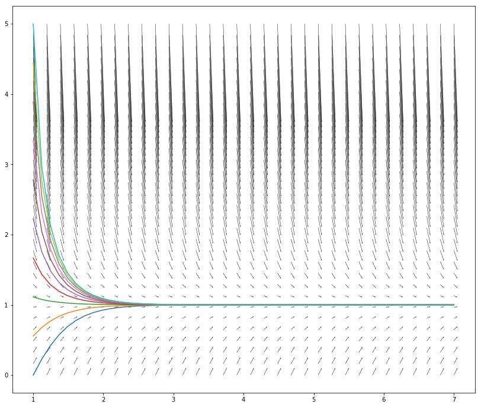

```python
from scipy.integrate import odeint
g = lambda y, t: 2 - y**2 - y

fig = plt.gcf()
fig.set_size_inches(14, 12)


X = np.linspace(1, 7, 32)
Y = np.linspace(0, 5, 32)

U = [1 for i in range(32)]
V = [f(i) for i in Y]

XX, YY = np.meshgrid(X, Y)


UU, VV = np.meshgrid(U, V)


plt.quiver(XX, YY, UU, VV, units='xy', width=0.004, scale=20)


for y0 in np.linspace(0, 5, 10):
    t = np.linspace(1, 7)
    r = odeint(g, y0, t)
    plt.plot(t, r)

plt.show()
```

### Task 2.2

Plot integral curves of given differential equation

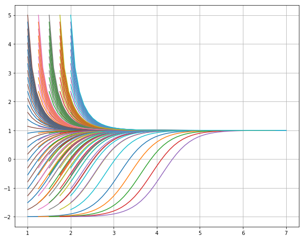

```python
fig = plt.gcf()
fig.set_size_inches(10, 8)

for y0 in np.linspace(-1.995, 5, 30):
    for t0 in np.linspace(1, 2, 5):
        t = np.linspace(t0, t0 + 5)
        r = odeint(g, y0, t)
        plt.plot(t, r)
plt.grid(axis='both')
plt.show()
```

$$2 - y - y^2 = 0| *(-1)$$$$y^2 + y - 2 = 0$$$$y = -2; y = 1$$

Hence, among other solutions, we got two, defined on $\mathbb{R}$ which are: $y \equiv -2; y \equiv 1$

### Task 2.3

Find all inflection points of integral curves

Inflection points of a function is defined by zeroes of its second derivative

$$y' = f(x, y)$$$$y'' = \frac{\partial f}{\partial x}dx + \frac {\partial f}{\partial y}dy = f^{'}_{x} + f^{'}_{y}y'$$

Substituting $y' = f(x, y)$

$$f^{'}_{x} + f^{'}_{y}f(x, y) = f^{'}_{x} + f^{'}_{y}f = 0$$$$f_{x}^{'} + f_{y}^{'}f = 0$$$$-(1 + 2y)(2 - y - y^2) = 0$$$$y = -\frac{1}{2}, y = -2, y = 1$$

Hence $y_i, i=1,..,3$ are geometric place of possible inflection points

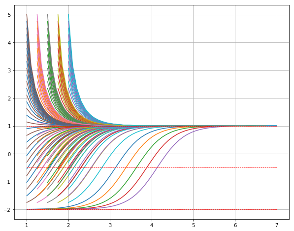

```python
fig = plt.gcf()
fig.set_size_inches(10, 8)

for y0 in np.linspace(-1.995, 5, 30):
    for t0 in np.linspace(1, 2, 5):
        t = np.linspace(t0, t0 + 5)
        r = odeint(g, y0, t)
        plt.plot(t, r)
plt.grid(axis='both')
t = np.linspace(1, 7, 2)
plt.plot(t, (-0.5, -0.5), 'r--', t, (-2, -2), 'r--', t, (1, 1), 'r--', linewidth=0.8)
plt.show()
```

As One can see, line $y \equiv -\frac{1}{2}$ is geometric place of inflection points

## Task 2.4

**Let $y(x, y_0), x \in I_{y_0}$ be a non-continuable solution, $y(0, y_0) = y_0$, find interval $I_{y_0}$**

$$y' = 2 - y^2 - y $$$$\frac{dy}{(y+2)(y-1)} = dx$$$$\int{\frac{dy}{(y+2)(y-1)}} = \int{dx}$$$$\int{\frac{dy}{(y+2)(y-1)}} = \frac{1}{3}\int{\bigg( \frac{1}{y - 1} - \frac{1}{y + 2} \bigg) dy}$$$$\ln{\bigg|\frac{y - 1}{y + 2}\bigg|} = 3x + C$$$$\frac{y - 1}{y + 2} = C_{1}e^{3x}$$

(Considering $y(0, y_0) = y_0$) $$\frac{y_0 - 1}{y_0 + 2} = C$$ Now let's derive $y(x, C)$ $$\frac{y - 1}{y + 2} = C_{1}e^{3x}$$ $$y - 1 = yCe^{3x} + 2Ce^{3x}$$ $$y(1 - Ce^{3x}) = 2Ce^{3x} + 1$$ $$y = \frac{2Ce^{3x} + 1}{1 - Ce^3x} = - \frac{2Ce^{3x} - 2 + 3}{Ce^{3x} - 1} = - \bigg(2 + \frac{3}{Ce^{3x} - 1} \bigg) = - 2 - \frac{3}{Ce^{3x} - 1} = - 2 + \frac{3}{C_1e^{3x} + 1} $$(minus sign in denominator absorbed)

if $y \equiv -2$, then $I_{y_0} = \mathbb{R}$, if $y \ne -2$ problem may occur when denominator turns into zero. $$\frac{y_0 - 1}{y_0 + 2} e^{3x} + 1 = 0, e^{3x} = -\frac{y_0 + 2}{y_0 - 1}$$, if $y_0 = 1 \implies x \in \emptyset$ else:

$e^{3x} \gt 0 \implies \frac{y_0 + 2}{y_0 - 1} \lt 0 \iff y \in (-2, 1) \implies$ if $y_0 \in (-2, 1)$ then $I_{y_0} = \mathbb{R}$

- if $y_0 < -2:$ then $x_0 = \frac{1}{3} \ln{\frac{y_0 - 2}{y_0 + 1}} = \frac{1}{3} \ln{\big(1 + \frac{3}{y_0 + 1}\big)}$; $y_0 < -2 \implies y_0 < - 1 \implies \frac{3}{y_0 + 1} < 0 \implies \frac{1}{3} \ln{\big(1 + \frac{3}{y_0 + 1}\big)} < 0 \implies I_{y_0} = (x_0, +\infty)$
- if $y_0 > 1$ then $x_0 = \frac{1}{3} \ln{\big(1 + \frac{3}{y_0 + 1}\big)}$; $y_0 > 1 \implies y_0 > 1 \implies \frac{3}{y_0 + 1} > 0 \implies \frac{1}{3} \ln{\big(1 + \frac{3}{y_0 + 1}\big)} > 0 \implies I_{y_0} = (-\infty, x_0)$

## Task 3.1

For given differential equation $y' = y^2 + x - 2$ plot it's vector field

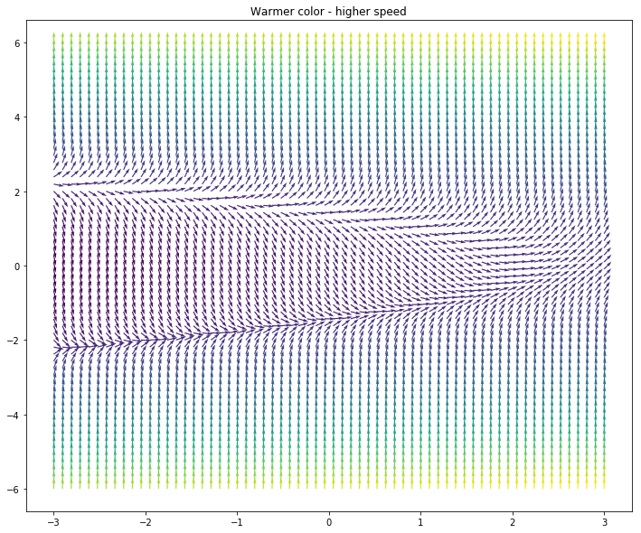

```python
def plotVectorField(f, xMin, xMax, yMin, yMax):
    fig = plt.gcf()
    fig.set_size_inches(12, 10)

    X = np.linspace(xMin, xMax, 64)
    Y = np.linspace(yMin, yMax, 64)

    XX, YY = np.meshgrid(X, Y)

    UU = np.cos(np.arctan(f(XX, YY)))
    VV = np.sin(np.arctan(f(XX, YY)))
    C = [[ f(x, y)*64 for x in X] for y in Y]
    plt.quiver(XX, YY, UU, VV, C, units='xy', width=0.02, scale=5)
    plt.title("Warmer color - higher speed")

f = lambda x, y: y**2 + x - 2
plotVectorField(f, -3, 3, -6, 6)
plt.show()
```

## Task 3.2

**Find and display maximums of diff. eq. solutions family**

$$y' = y^2 + x - 2; y^2 + x - 2 = 0; y = \pm \sqrt{2 - x}$$

$y = \pm \sqrt{2 - x}$ - Geometric place of possible minimum\maximum points

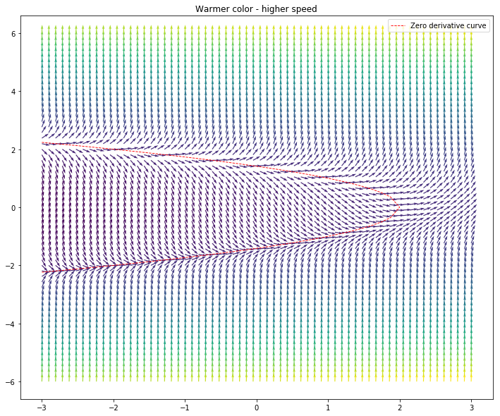

```python
plotVectorField(f, -3, 3, -6, 6)

x = np.linspace(-3, 2, 40)
plt.plot(x, (2 - x)**0.5, 'r--', linewidth=0.9, label='Zero derivative curve')
plt.plot(x, -(2 - x)**0.5, 'r--', linewidth=0.9)
plt.legend()
plt.show()
```

## Task 3.3

**Display isoclines of diff. equation for given k:** $k=1, 2, 3$

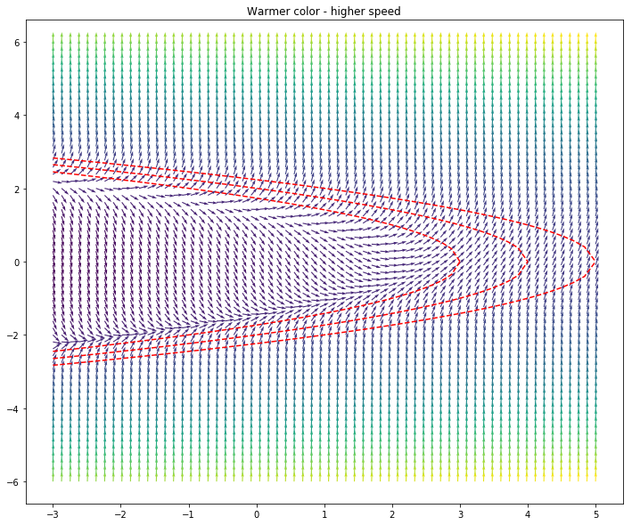

```python
plotVectorField(f, -3, 5, -6, 6)

g = lambda x: (2 + k - x)**0.5

vf = np.vectorize(g)

for k in range(1, 4):
    x = np.linspace(-3, 2 + k)
    y = vf(x)
    leg = "k=" + str(k)
    plt.plot(x, y, 'r--', label=leg)
    plt.plot(x, -y, 'r--')
plt.show()
```

## Task 3.4, 3.5

Show areas of integral curves ascend and descend

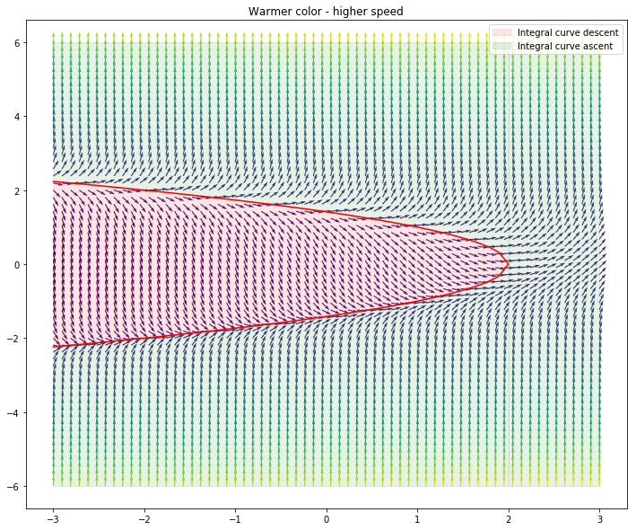

```python
plotVectorField(f, -3, 3, -6, 6)

g = lambda x: (2 - x)**0.5

g = np.vectorize(g)

x = np.linspace(-3, 2)
t = np.linspace(2, 3)
y1, y2 = g(x), -g(x)

plt.plot(x, y1, 'r')
plt.plot(x, y2, 'r')
area1 = plt.fill_between(x, y1, y2, alpha=0.1, color='r')
area2 = plt.fill_between(x, y1, 6, alpha=0.1, color='g')
plt.fill_between(x, -6, y2, alpha=0.1, color='g')
plt.fill_between(t, -6, 6, alpha=0.1, color='g')
plt.legend((area1, area2), ("Integral curve descent", "Integral curve ascent"))
plt.show()
```

## Task 3.6

Find and draw geometric place of integral curves family inflection points

$$y'' = f_{x}^{'} + f_{y}^{'}f = 0$$$$1+2y(y^2 + x - 2) = 0$$$$2y^3 + 2xy - 4y + 1 = 0$$

Last equation defines geometric place of possible inflection points

Here we will use sympy to plot implicit graph, after it we will gather points from it and plot it upon our vector field

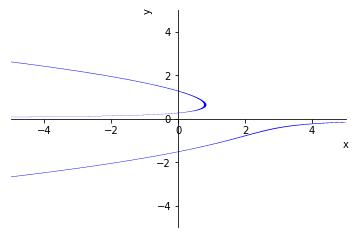

```python
from sympy import var, plot_implicit

res = []
var('x y')
s = plot_implicit(2*y**3 + 2*x*y - 4*y + 1).__dict__["_series"]
intervals = s[0].get_raster()[0]
for v in intervals:
    x, y = v[0].start, v[1].start
    res.append((x, y))
```

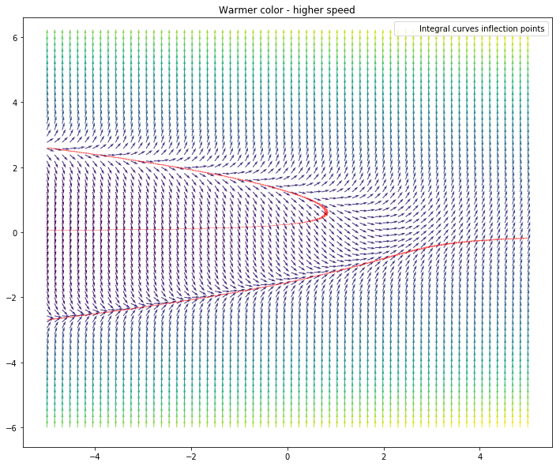

```python
plotVectorField(f, -5, 5, -6, 6)

fig = plt.gcf()
fig.set_size_inches(12, 10)

X, Y = zip(*res)
line = plt.scatter(X, Y, c='r', s=0.005)
plt.legend((line, ), ("Integral curves inflection points",))
plt.show()
```

## Task 3.7

Highlight areas where integral curves are inflected upwards

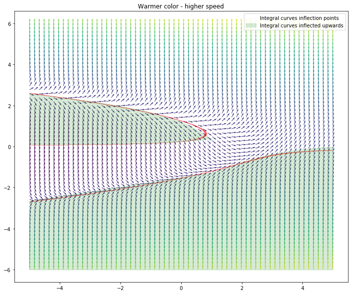

```python
plotVectorField(f, -5, 5, -6, 6)

fig = plt.gcf()
fig.set_size_inches(12, 10)

x = np.linspace(-5, 1)

x2 = np.linspace(1.02, 5)

y = np.exp(0.8*x -2) + 0.1
y2 = np.log(-1.2*x + 2) + 0.485
y3 = 0.23*x - 1.5
y4 = 0.85*np.arctan(0.6*x2 - 1) - 0.95

X, Y = zip(*res)
line = plt.scatter(X, Y, c='r', s=0.005)
area = plt.fill_between(x, y2, y, color='g', alpha=0.16)
plt.fill_between(x, -6, y3, color='g', alpha=0.16)
plt.fill_between(x2, -6, y4, color='g', alpha=0.16)
plt.legend((line, area), ("Integral curves inflection points", "Integral curves inflected upwards"))
plt.show()
```

```python
def rungeKuta(f, x0, y0, h, n):
    res = []
    res.append(y0)
    for i in range(n - 1):
        k1 = f(x0, y0)
        k2 = f(x0 + h/2, y0 + (h*k1)/2)
        k3 = f(x0 + h/2, y0 + (h*k2)/2)
        k4 = f(x0 + h, y0 + h*k3)
        y0 += (h/6) * (k1 + 2*k2 + 2*k3 + k4)
        x0 += h
        res.append(y0)
    return res


def adamsMethod(f, x0, y0, a, b, n):
    h = (b - a)/n
    y1, y2, y3, y4 = odeint(f, y0, np.linspace(x0, x0 + 4*h, 4))
#     y1, y2, y3, y4 = rungeKuta(f, x0, y0, h, 4)
    x1, x2, x3, x4 = np.linspace(x0, x0 + 4*h, 4)
    res = [y1, y2, y3, y4]
    for i in range(n - 4):
        ya = y4 + (h/24)*(-9*f(x1, y1) + 37*f(x2, y2) - 59*f(x3, y3) + 55*f(x4, y4))
        xa = x4 + h
        y = y4 + (h/24)*(f(x2, y2) - 5*f(x3, y3) + 19*f(x4, y4) + 9*f(xa, ya))
        y1, y2, y3, y4 = y2, y3, y4, ya
        x1, x2, x3, x4 = x2, x3, x4, xa
        res.append(y)
    return res
```

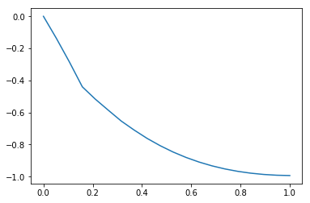

```python
y0 = 0

t = np.linspace(0, 1, 20)

cur = adamsMethod(f, 0, 0, 0, 1, 20)
plt.plot(t, cur)

plt.show()
```